# Time Series Analysis/Forecasting and Univariate ARIMA Models

```python
import os
import sys
import warnings
from datetime import date
import pandas as pd
import pandas_datareader.data as web
import numpy as np
from numpy.linalg import LinAlgError

import statsmodels.tsa.api as tsa
from statsmodels.graphics.tsaplots import plot_acf, acf, plot_pacf, pacf
from statsmodels.tsa.stattools import acf, q_stat, adfuller
import statsmodels.api as sm
from scipy.stats import probplot, moment
from sklearn.metrics import mean_squared_error

import seaborn as sns
import matplotlib.pyplot as plt
import matplotlib as mpl
```

```python
%matplotlib inline
warnings.filterwarnings('ignore')
sns.set(style="darkgrid", color_codes=True)
```

```python
def plot_correlogram(x, lags=None, title=None):
    lags = min(10, int(len(x)/5)) if lags is None else lags
    fig, axes = plt.subplots(nrows=2, ncols=2, figsize=(13, 8))
    x.plot(ax=axes[0][0])
    q_p = np.max(q_stat(acf(x, nlags=lags), len(x))[1])
    stats = f'Q-Stat: {np.max(q_p):>8.2f}\nADF: {adfuller(x)[1]:>11.2f}'
    axes[0][0].text(x=.02, y=.85, s=stats, transform=axes[0][0].transAxes)
    probplot(x, plot=axes[0][1])
    mean, var, skew, kurtosis = moment(x, moment=[1, 2, 3, 4])
    s = f'Mean: {mean:>12.2f}\nSD: {np.sqrt(var):>16.2f}\nSkew: {skew:12.2f}\nKurtosis:{kurtosis:9.2f}'
    axes[0][1].text(x=.02, y=.75, s=s, transform=axes[0][1].transAxes)
    plot_acf(x=x, lags=lags, zero=False, ax=axes[1][0])
    plot_pacf(x, lags=lags, zero=False, ax=axes[1][1])
    axes[1][0].set_xlabel('Lag')
    axes[1][1].set_xlabel('Lag')
    fig.suptitle(title, fontsize=20)
    fig.tight_layout()
    fig.subplots_adjust(top=.9)
```

## Download Series

Load monthly **`Industrial Production`** and daily **`NASDAQ`** stock market index:

```python
industrial_production = web.DataReader('IPGMFN', 'fred', '1988', '2020-02').squeeze().dropna()
nasdaq = web.DataReader('NASDAQCOM', 'fred', '1990', '2020-03-31').squeeze().dropna()
```

```python
industrial_production
```

```
DATE
1988-01-01     56.7982
1988-02-01     58.0084
1988-03-01     58.6871
1988-04-01     58.9176
1988-05-01     59.0147
                ...
2019-10-01    106.2767
2019-11-01    105.7610
2019-12-01    104.4315
2020-01-01    103.4507
2020-02-01    105.4971
Name: IPGMFN, Length: 386, dtype: float64
```

```python
nasdaq
```

```
DATE
1990-01-02     459.330
1990-01-03     460.900
1990-01-04     459.390
1990-01-05     458.220
1990-01-08     458.710
                ...
2020-03-25    7384.297
2020-03-26    7797.535
2020-03-27    7502.379
2020-03-30    7774.152
2020-03-31    7700.098
Name: NASDAQCOM, Length: 7622, dtype: float64
```

## Plot Series

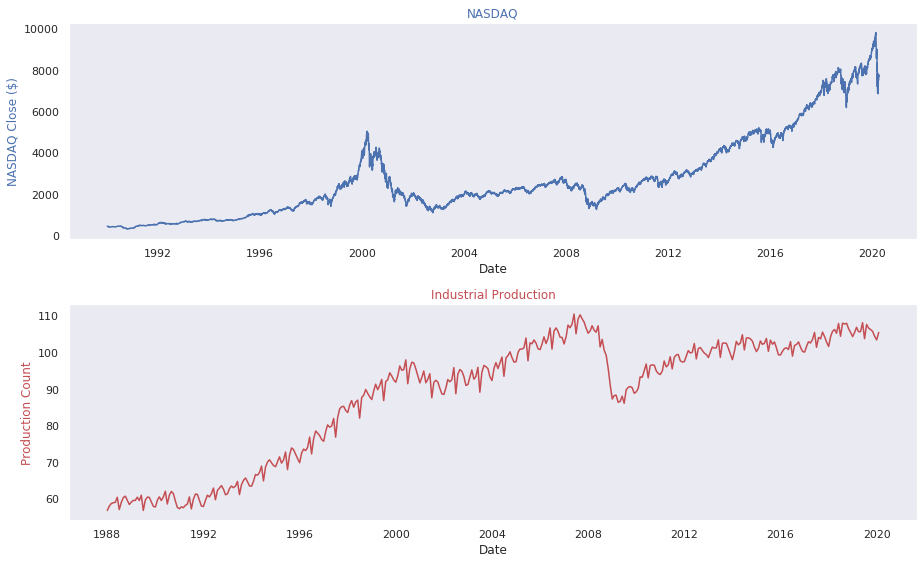

```python
fig, ax = plt.subplots(2,1,figsize=(13, 8))

ax[0].plot(nasdaq, color='b')
ax[1].plot(industrial_production, color='r')

ax[0].set_xlabel('Date')
ax[1].set_xlabel('Date')

ax[0].set_title('NASDAQ', color='b')
ax[1].set_title('Industrial Production', color='r')

ax[0].set_ylabel('NASDAQ Close ($)', color='b')
ax[1].set_ylabel('Production Count', color='r')

ax[0].grid(False)
ax[1].grid(False)

plt.tight_layout()
plt.show()
```

## Additive Decomposition

Time series data typically contains a mix of various patterns that can be decomposed into several components, each representing an underlying pattern category. In particular, time series often consist of the systematic components **`trend, seasonality and cycles, and unsystematic noise(white noise)`**. These components can be combined in an additive, linear model, in particular when fluctuations do not depend on the level of the series, or in a non-linear, multiplicative model.

These components can be split up automatically. **`statsmodels`** includes a simple method to split the time series into a trend, seasonal, and residual component using *moving averages*. We can apply it to monthly data on industrial manufacturing production with both a strong trend and seasonality component, as follows:

```python
components = tsa.seasonal_decompose(industrial_production, model='additive')
```

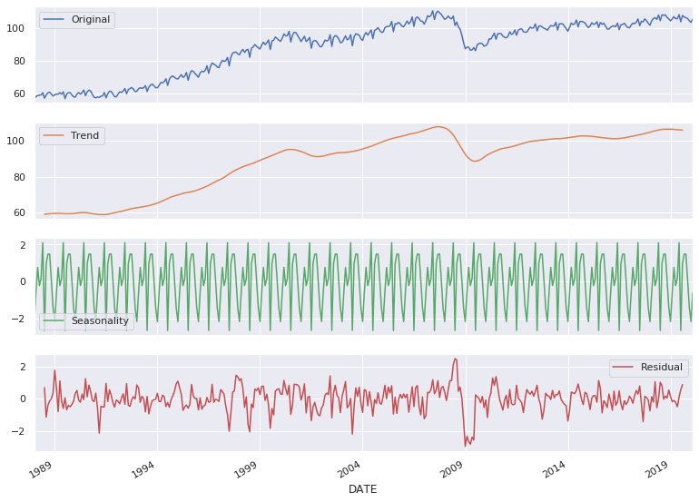

```python
ts = (industrial_production.to_frame('Original')
      .assign(Trend=components.trend)
      .assign(Seasonality=components.seasonal)
      .assign(Residual=components.resid))

ts.plot(subplots=True, figsize=(13, 10))
plt.show()
```

## Time Series Stationarity

The statistical properties, such as the **mean, variance, or autocorrelation, of a `stationary` time series don't change over time**. Hence, `stationarity implies that a time series does not have any trend or seasonal effects and that descriptive statistics, such as the mean or the standard deviation, when computed for different rolling windows, remain constant or do not change much over time`. It reverts to its mean, and the deviations have constant amplitude, while short-term movements always look fairly similar.

Strict stationarity requires the joint distribution of any subset of time series observations to be independent of time with respect to all moments. So, in addition to the mean and variance, higher moments such as skew and kurtosis, also need to be constant, irrespective of the lag between different observations. **In most applications, we limit stationarity to first and second moments** so that the time series is covariance stationary with constant mean, variance, and autocorrelation.

Note that we specifically `allow for dependence between observations at different lags`, just like we want the input data for linear regression to be correlated with the outcome. Stationarity implies that these relationships are stable, which facilitates prediction as the model can focus on learning systematic patterns that take place within stable statistical properties.

To satisfy the stationarity assumption of linear time series models, we need to transform the original time series, often in several steps. Common transformations include:

- Taking the **(natural) logarithm** to convert an exponential growth pattern into a linear trend and stabilize the variance.
- **Deflation** implies `dividing` a time series by another series that causes trending behavior, for example dividing a nominal series by a price index to convert it into a real measure.
- **Differencing** a time-series meaning for each value in the time-series we subtract its previous value.

[figure not shown]

Other Transformations:

- Take the **square root:**
  - **`np.sqrt(df)`**
- Take the **proportional change:**
  - **`df.shift(1)/df`**

### Test for stationarity

The **`augmented Dicky-Fuller test`**

- Tests for **trend** non-stationarity
- Null hypothesis is time series is non-stationary

```python
adf = adfuller(industrial_production)

print(f'Test Statistic: {adf[0]}')
print(f'\nP-Value: {adf[1]}')
print(f'\nCritical Values: {adf[4]}')
```

```
Test Statistic: -1.5867425644697801

P-Value: 0.4902496718328939

Critical Values: {'1%': -3.448196541708585, '5%': -2.869404683789669, '10%': -2.5709597356805545}
```

- `0th` element is test statistic (-1.59)
  - More negative means more likely to be stationary
- `1st` element is p-value: (0.49)
  - If p-value is small → reject null hypothesis. Reject non-stationary.
- `4th` element is the critical test statistics

### Log Transformation

Check for zero values

```python
(nasdaq == 0).any(), (industrial_production==0).any()
```

```
(False, False)
```

```python
nasdaq_log = np.log(nasdaq)
industrial_production_log = np.log(industrial_production)
```

### Differencing

In many cases, de-trending is not sufficient to make the series stationary. Instead, we need to transform the original data into a series of period-to-period and/or season-to-season differences. Note that when such differencing is applied to a log-transformed series, the results represent instantaneous growth rates or returns in a financial context.

If a univariate series becomes stationary after differencing `d` times, it is said to be integrated of the order of `d`, or simply integrated if `d=1`. This behavior is due to so-called *unit roots*.

- **What is “Unit Root”?**
  - A unit root (also called a unit root process or a difference stationary process) is a stochastic trend in a time series, sometimes called a “random walk with drift”; If a time series has a unit root, it shows a systematic pattern that is unpredictable.

Differencing of log series produces instantaneous returns.

```python
nasdaq_log_diff = nasdaq_log.diff().dropna()

# seasonal differencing of 12 = yoy instantanteous returns
industrial_production_log_diff = industrial_production_log.diff(12).dropna()
```

### Plot Series

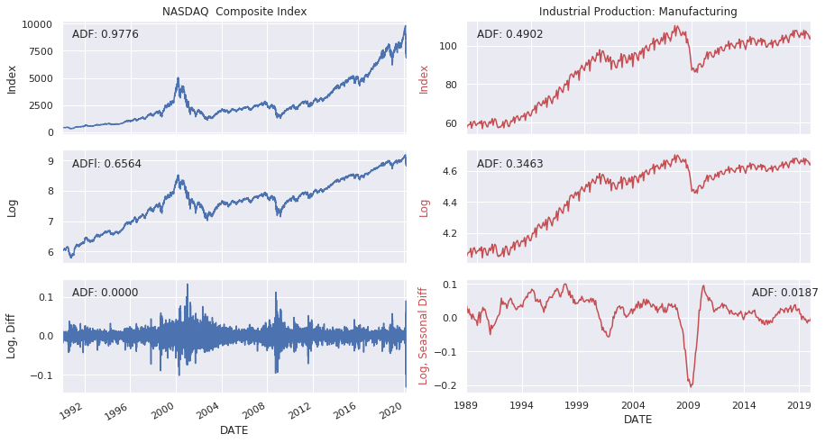

```python
fig, axes = plt.subplots(nrows=3, ncols=2, figsize=(13,7))

nasdaq.plot(ax=axes[0][0], title='NASDAQ  Composite Index')
axes[0][0].text(x=.03, y=.85, s=f'ADF: {tsa.adfuller(nasdaq.dropna())[1]:.4f}', transform=axes[0][0].transAxes)
axes[0][0].set_ylabel('Index')

nasdaq_log.plot(ax=axes[1][0], sharex=axes[0][0])
axes[1][0].text(x=.03, y=.85, s=f'ADFl: {tsa.adfuller(nasdaq_log.dropna())[1]:.4f}', transform=axes[1][0].transAxes)
axes[1][0].set_ylabel('Log')

nasdaq_log_diff.plot(ax=axes[2][0], sharex=axes[0][0])
axes[2][0].text(x=.03, y=.85, s=f'ADF: {tsa.adfuller(nasdaq_log_diff.dropna())[1]:.4f}', transform=axes[2][0].transAxes)
axes[2][0].set_ylabel('Log, Diff')

industrial_production.plot(ax=axes[0][1], title='Industrial Production: Manufacturing', color='r')
axes[0][1].text(x=.03, y=.85, s=f'ADF: {tsa.adfuller(industrial_production)[1]:.4f}', transform=axes[0][1].transAxes)
axes[0][1].set_ylabel('Index', color='r')

industrial_production_log.plot(ax=axes[1][1], sharex=axes[0][1], color='r')
axes[1][1].text(x=.03, y=.85, s=f'ADF: {tsa.adfuller(industrial_production_log.dropna())[1]:.4f}', transform=axes[1][1].transAxes)
axes[1][1].set_ylabel('Log', color='r')

industrial_production_log_diff.plot(ax=axes[2][1], sharex=axes[0][1], color='r')
axes[2][1].text(x=.83, y=.85, s=f'ADF: {tsa.adfuller(industrial_production_log_diff.dropna())[1]:.4f}', transform=axes[2][1].transAxes)
axes[2][1].set_ylabel('Log, Seasonal Diff', color='r')
fig.tight_layout()
fig.align_ylabels(axes);
```

## Correlogram

**`Autocorrelation`** (also called serial correlation) adapts the concept of correlation to the time series context: just as the correlation coefficient measures the strength of a linear relationship between two variables, the autocorrelation coefficient, $\rho_k$, measures the extent of a linear relationship between time series values separated by a given lag, $k$.

Hence, we can calculate one autocorrelation coefficient for each of the `T-1` lags in a time series; `T` is the length of the series. The `autocorrelation function (ACF)` computes the correlation coefficients as a function of the lags.

The autocorrelation for a lag larger than `1` (that is, between observations more than one time step apart) reflects both the direct correlation between these observations and the indirect influence of the intervening data points.

The `partial autocorrelation function (PACF)` removes this influence and only measures the linear dependence between data points at the given lag distance. The (PACF) provides all the correlations that result once the effects of correlation at shorter lags have been removed.

A correlogram is simply a plot of the ACF or PACF for sequential lags, `k=0,1,...,n`. It allows us to inspect the correlation structure across lags at one glance. The main usage of correlograms is to detect any autocorrelation after the removal of the effects of trend or seasonality. Both the ACF and the PACF are key diagnostic tools for the design of linear time series models.

[figure not shown]

### NASDAQ (log, diff)

We can further analyze the relevant time series characteristics for the transformed series using a **`Q-Q plot`** that compares the quantiles of the distribution of the time series observation to the quantiles of the normal distribution and the correlograms based on the ACF and PACF.

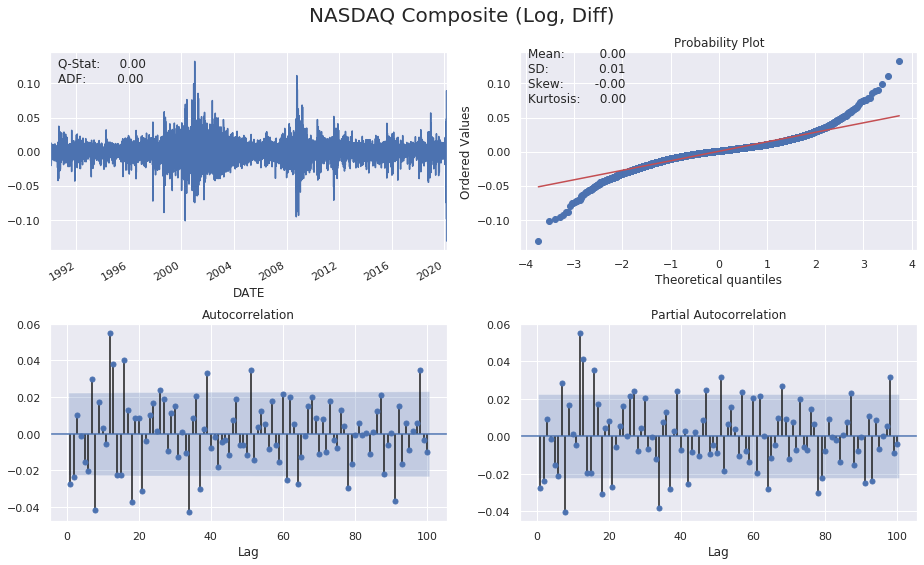

```python
plot_correlogram(nasdaq_log_diff, lags=100, title='NASDAQ Composite (Log, Diff)')
```

### Industrial Production (log, seasonl diff)

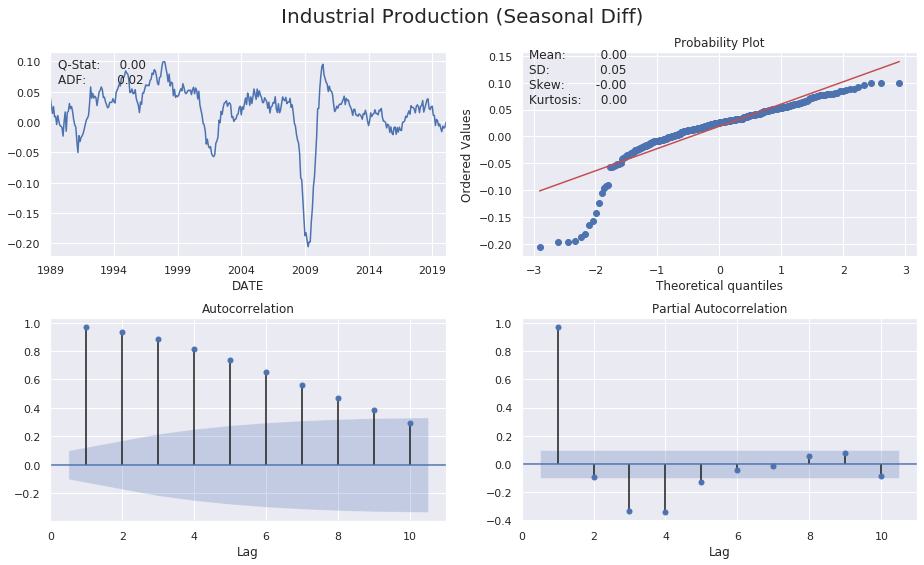

```python
plot_correlogram(industrial_production_log_diff, title='Industrial Production (Seasonal Diff)')
```

## Univariate Time Series Models

### Autoregressive (AR) Model

Multiple linear-regression models expressed the variable of interest as a linear combination of predictors or input variables. Univariate time series models relate the value of the time series at the point in time of interest to a linear combination of lagged values of the series and possibly past disturbance terms. While exponential smoothing models are based on a description of the trend and seasonality in the data, `ARIMA` models aim to describe the autocorrelations in the data. `ARIMA(p, d, q)`.

- **p** - number of autoregressive lags
- **d** - order of differencing
- **q** - number of moving average lags

**Models require stationarity and leverage two building blocks:**

- **Autoregressive (AR)** terms consisting of `p-lagged` values of the time series

[figure not shown]

- **Moving average (MA)** terms that contain `q-lagged` disturbances

[figure not shown]

### ARMA vs ARIMA

```python
model1 = tsa.ARMA(endog=nasdaq_log_diff, order=(2,2)).fit()
model2 = tsa.ARIMA(endog=nasdaq_log, order=(2,1,2)).fit()
```

```python
model1.params.sort_index() == model2.params.sort_index().values
```

```
ar.L1.NASDAQCOM    True
ar.L2.NASDAQCOM    True
const              True
ma.L1.NASDAQCOM    True
ma.L2.NASDAQCOM    True
dtype: bool
```

### Seasonal differencing vs SARIMAX

[figure not shown]

**Seasonal data**

- Has predictable and repeated patterns
- Repeats after any amount of time

[figure not shown]

```python
model1 = tsa.statespace.SARIMAX(industrial_production_log, order=(2,0,2), seasonal_order=(0,1,0,12)).fit()
model2 = tsa.statespace.SARIMAX(industrial_production_log_diff, order=(2,0,2), seasonal_order=(0,0,0,12)).fit()
```

```python
model1.params.to_frame('SARIMAX').join(model2.params.to_frame('diff'))
```

|  | SARIMAX | diff |
| --- | --- | --- |
| ar.L1 | 1.772617 | 1.810456 |
| ar.L2 | -0.793977 | -0.832465 |
| ma.L1 | -0.853340 | -0.915161 |
| ma.L2 | 0.289099 | 0.334137 |
| sigma2 | 0.000100 | 0.000099 |

## Finding the optimal ARMA lags

### Run candidate models

We iterate over various `(p, q)` lag combinations and collect diagnostic statistics to compare the result.

```python
train_size = 120 # 10 years of training data
test_results = {}
y_true = industrial_production_log_diff.iloc[train_size:]
for p in range(5):
    for q in range(5):
        aic, bic = [], []
        if p == 0 and q == 0:
            continue
        print(f'p:{p}, q:{q}')
        convergence_error = stationarity_error = 0
        y_pred = []
        for T in range(train_size, len(industrial_production_log_diff)):
            train_set = industrial_production_log_diff.iloc[T-train_size:T]
            try:
                model = tsa.ARMA(endog=train_set, order=(p, q)).fit()
            except LinAlgError:
                convergence_error += 1
            except ValueError:
                stationarity_error += 1

            forecast, _, _ = model.forecast(steps=1)
            y_pred.append(forecast[0])
            aic.append(model.aic)
            bic.append(model.bic)

        result = (pd.DataFrame({'y_true': y_true, 'y_pred': y_pred})
                  .replace(np.inf, np.nan)
                  .dropna())

        rmse = np.sqrt(mean_squared_error(
            y_true=result.y_true, y_pred=result.y_pred))

        test_results[(p, q)] = [rmse,
                                np.mean(aic),
                                np.mean(bic),
                                convergence_error,
                                stationarity_error]
```

```
p:0, q:1
p:0, q:2
p:0, q:3
p:0, q:4
p:1, q:0
p:1, q:1
p:1, q:2
p:1, q:3
p:1, q:4
p:2, q:0
p:2, q:1
p:2, q:2
p:2, q:3
p:2, q:4
p:3, q:0
p:3, q:1
p:3, q:2
p:3, q:3
p:3, q:4
p:4, q:0
p:4, q:1
p:4, q:2
p:4, q:3
p:4, q:4
```

## AIC and BIC

**`AIC`** = **Akaike information criterion**

- A Lower AIC indicates a better model
- AIC likes to choose simpler models with a lower order

**`BIC`** = **Bayesian information criterion**

- Very similar to AIC
- A Lower BIC indicates a better model

**AIC vs BIC**

- BIC favors simpler models than AIC
- AIC is better at choosing predictive models
- BIC is better at choosing good explanatory model

```python
test_results = pd.DataFrame(test_results).T
test_results.columns = ['RMSE', 'AIC', 'BIC', 'convergence', 'stationarity']
test_results.index.names = ['p', 'q']
test_results.info()
```

```
<class 'pandas.core.frame.DataFrame'>
MultiIndex: 24 entries, (0, 1) to (4, 4)
Data columns (total 5 columns):
RMSE            24 non-null float64
AIC             24 non-null float64
BIC             24 non-null float64
convergence     24 non-null float64
stationarity    24 non-null float64
dtypes: float64(5)
memory usage: 1.2 KB
```

```python
# Sort by AIC
test_results.sort_values('AIC').head()
```

| p | q | RMSE | AIC | BIC | convergence | stationarity |
| --- | --- | --- | --- | --- | --- | --- |
| 3 | 4 | 0.040955 | -762.945922 | -737.858496 | 2.0 | 57.0 |
| 4 | 3 | 0.029127 | -761.548114 | -736.460688 | 2.0 | 43.0 |
|  | 4 | 0.028428 | -761.079428 | -733.204511 | 3.0 | 61.0 |
| 3 | 3 | 0.009729 | -760.025170 | -737.725236 | 2.0 | 16.0 |
| 4 | 2 | 0.013280 | -759.873059 | -737.573125 | 0.0 | 5.0 |

```python
# Sort by BIC
test_results.sort_values('BIC').head()
```

| p | q | RMSE | AIC | BIC | convergence | stationarity |
| --- | --- | --- | --- | --- | --- | --- |
| 2 | 2 | 0.012349 | -759.250415 | -742.525465 | 0.0 | 4.0 |
| 4 | 0 | 0.010137 | -758.286914 | -741.561963 | 0.0 | 0.0 |
|  | 1 | 0.009938 | -759.535290 | -740.022848 | 0.0 | 3.0 |
| 3 | 1 | 0.011521 | -755.575064 | -738.850114 | 1.0 | 5.0 |
|  | 4 | 0.040955 | -762.945922 | -737.858496 | 2.0 | 57.0 |

```python
# Sort by RMSE
test_results.sort_values('RMSE').head()
```

| p | q | RMSE | AIC | BIC | convergence | stationarity |
| --- | --- | --- | --- | --- | --- | --- |
| 3 | 3 | 0.009729 | -760.025170 | -737.725236 | 2.0 | 16.0 |
| 4 | 1 | 0.009938 | -759.535290 | -740.022848 | 0.0 | 3.0 |
|  | 0 | 0.010137 | -758.286914 | -741.561963 | 0.0 | 0.0 |
| 3 | 0 | 0.010525 | -748.316444 | -734.378985 | 0.0 | 0.0 |
| 1 | 0 | 0.011284 | -727.177753 | -718.815278 | 0.0 | 0.0 |

We aim to minimize **`RMSE`**:

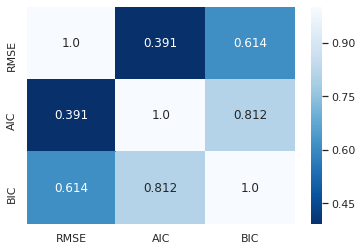

```python
sns.heatmap(test_results[['RMSE', 'AIC', 'BIC']].corr('spearman'), fmt='.3', annot=True, cmap='Blues_r')
b, t = plt.ylim()
b += 0.5
t -= 0.5
plt.ylim(b, t)
plt.show()
```

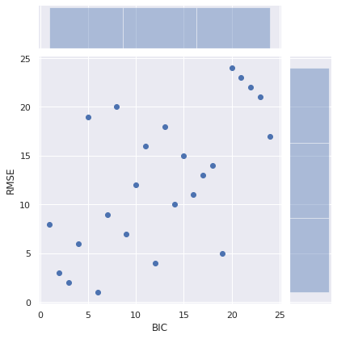

```python
sns.jointplot(y='RMSE', x='BIC', data=test_results[['RMSE', 'BIC']].rank());
```

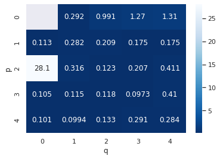

```python
sns.heatmap(test_results.RMSE.unstack().mul(10), fmt='.3', annot=True, cmap='Blues_r')
b, t = plt.ylim()
b += 0.5
t -= 0.5
plt.ylim(b, t)
plt.show()
```

We also aim to minimize **`BIC`**:

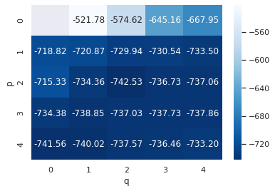

```python
sns.heatmap(test_results.BIC.unstack(), fmt='.2f', annot=True, cmap='Blues_r')
b, t = plt.ylim()
b += 0.5
t -= 0.5
plt.ylim(b, t)
plt.show()
```

### Estimating the best ARMA Model

```python
# Just an ARMA(p,q) model
model = tsa.SARIMAX(endog=industrial_production_log_diff, order=(2, 0, 2))

results = model.fit()

print(results.summary())
```

```
                               SARIMAX Results
==============================================================================
Dep. Variable:                 IPGMFN   No. Observations:                  374
Model:               SARIMAX(2, 0, 2)   Log Likelihood                1190.533
Date:                Fri, 10 Apr 2020   AIC                          -2371.067
Time:                        02:14:37   BIC                          -2351.446
Sample:                    01-01-1989   HQIC                         -2363.276
                         - 02-01-2020
Covariance Type:                  opg
==============================================================================
                 coef    std err          z      P>|z|      [0.025      0.975]
------------------------------------------------------------------------------
ar.L1          1.8105      0.042     42.813      0.000       1.728       1.893
ar.L2         -0.8325      0.041    -20.287      0.000      -0.913      -0.752
ma.L1         -0.9152      0.061    -15.101      0.000      -1.034      -0.796
ma.L2          0.3341      0.051      6.562      0.000       0.234       0.434
sigma2       9.94e-05   6.47e-06     15.367      0.000    8.67e-05       0.000
===================================================================================
Ljung-Box (Q):                      101.73   Jarque-Bera (JB):                 9.04
Prob(Q):                              0.00   Prob(JB):                         0.01
Heteroskedasticity (H):               0.61   Skew:                            -0.16
Prob(H) (two-sided):                  0.01   Kurtosis:                         3.69
===================================================================================

Warnings:
[1] Covariance matrix calculated using the outer product of gradients (complex-step).
```

[figure not shown]

### Plot diagnostics

If the model ts well the residuals will be white Gaussian noise.

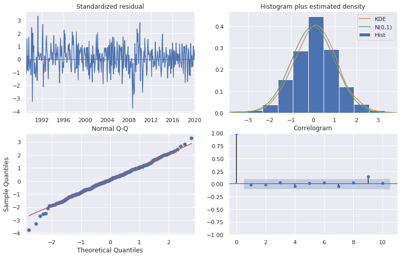

```python
# Create the 4 diagostics plots
results.plot_diagnostics(figsize=(13, 8))
plt.show()
```

### Making one-step-ahead predictions

```python
# Make in-sample predictions for last 30 values
forecast = results.get_prediction(start=-30)

# forecast mean
mean_forecast = forecast.predicted_mean

# Get confidence intervals of forecasts
confidence_intervals = forecast.conf_int()

# Select lower and upper confidence limits
lower_limits = confidence_intervals.loc[:,'lower IPGMFN']
upper_limits = confidence_intervals.loc[:,'upper IPGMFN']
```

### Plotting predictions

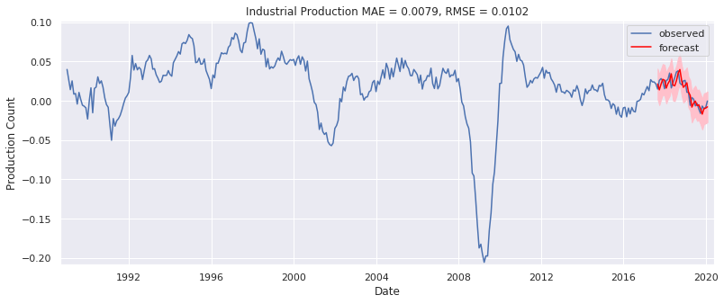

```python
plt.figure(figsize=(13, 5))

# plot the amazon data
plt.plot(industrial_production_log_diff.dropna().index, industrial_production_log_diff.dropna(), label='observed')

# Plot prediction
plt.plot(mean_forecast.index, mean_forecast.values, color='red', label='forecast')

# Shade uncertainty area
plt.fill_between(confidence_intervals.index, lower_limits, upper_limits, color='pink')

# Calculate MAE
residuals = results.resid
mae = np.mean(np.abs(residuals))

# Calculate RMSE
preds = pd.DataFrame(results.forecasts).T
preds.index = industrial_production_log_diff.dropna().index
preds. columns = ['pred']

rmse = np.sqrt(mean_squared_error(
            y_true=industrial_production_log_diff.dropna(), y_pred=preds.pred))

# set labels, legends and show plot
plt.xlabel('Date')
plt.title(f'Industrial Production MAE = {round(mae,4)}, RMSE = {round(rmse,4)}')
plt.ylabel('Production Count')
plt.margins(0.01)
plt.legend()
plt.show()
```

### Forecasting out of sample

```python
# forecast next 30 days
forecast = results.get_forecast(steps=30)

# forecast mean
mean_forecast = forecast.predicted_mean

# Get confidence intervals of forecasts
confidence_intervals = forecast.conf_int()

# Select lower and upper confidence limits
lower_limits = confidence_intervals.loc[:,'lower IPGMFN']
upper_limits = confidence_intervals.loc[:,'upper IPGMFN']
```

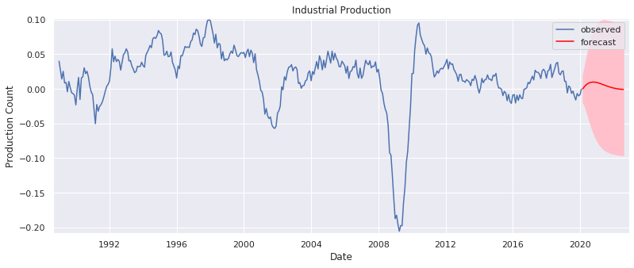

```python
plt.figure(figsize=(13, 5))

# plot the amazon data
plt.plot(industrial_production_log_diff.dropna().index, industrial_production_log_diff.dropna(), label='observed')

# Plot prediction
plt.plot(mean_forecast.index, mean_forecast.values, color='red', label='forecast')

# Shade uncertainty area
plt.fill_between(confidence_intervals.index, lower_limits, upper_limits, color='pink')

# set labels, legends and show plot
plt.xlabel('Date')
plt.title('Industrial Production')
plt.ylabel('Production Count')
plt.margins(0.01)
plt.legend()
plt.show()
```

### Reconstructing original time series after differencing

```python
diff_forecast = results.get_forecast(steps=30).predicted_mean

from numpy import cumsum

mean_forecast = cumsum(diff_forecast) + pd.DataFrame(industrial_production).iloc[-1,0]
```

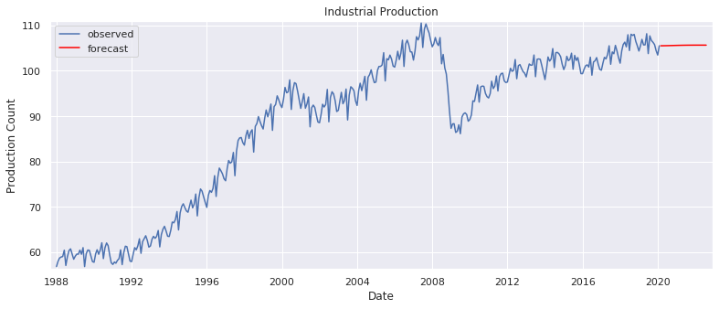

```python
plt.figure(figsize=(13, 5))

# plot the amazon data
plt.plot(industrial_production.index, industrial_production, label='observed')

# Plot prediction
plt.plot(mean_forecast.index, mean_forecast.values, color='red', label='forecast')

# set labels, legends and show plot
plt.xlabel('Date')
plt.title('Industrial Production')
plt.ylabel('Production Count')
plt.margins(x=0.01, y=0.01)
plt.legend()
plt.show()
```

## SARIMAX

```python
model = tsa.SARIMAX(endog=industrial_production_log_diff.dropna(),
                    order=(2, 0, 2),
                    seasonal_order=(1, 0, 1, 12))

results = model.fit(start_params=[0, 0, 0, 0, 0, 0, 1])

print(results.summary())
```

```
                                      SARIMAX Results
============================================================================================
Dep. Variable:                               IPGMFN   No. Observations:                  374
Model:             SARIMAX(2, 0, 2)x(1, 0, [1], 12)   Log Likelihood                1219.719
Date:                              Fri, 10 Apr 2020   AIC                          -2425.439
Time:                                      02:14:41   BIC                          -2397.969
Sample:                                  01-01-1989   HQIC                         -2414.532
                                       - 02-01-2020
Covariance Type:                                opg
==============================================================================
                 coef    std err          z      P>|z|      [0.025      0.975]
------------------------------------------------------------------------------
ar.L1          0.1270      0.334      0.381      0.703      -0.527       0.781
ar.L2          0.8598      0.332      2.588      0.010       0.209       1.511
ma.L1          0.8565      0.338      2.536      0.011       0.195       1.518
ma.L2          0.0195      0.044      0.445      0.656      -0.066       0.105
ar.S.L12       0.0282      0.080      0.352      0.725      -0.129       0.186
ma.S.L12      -0.6946      0.059    -11.688      0.000      -0.811      -0.578
sigma2      8.655e-05    5.6e-06     15.448      0.000    7.56e-05    9.75e-05
===================================================================================
Ljung-Box (Q):                      113.65   Jarque-Bera (JB):                56.28
Prob(Q):                              0.00   Prob(JB):                         0.00
Heteroskedasticity (H):               0.60   Skew:                            -0.42
Prob(H) (two-sided):                  0.00   Kurtosis:                         4.71
===================================================================================

Warnings:
[1] Covariance matrix calculated using the outer product of gradients (complex-step).
```

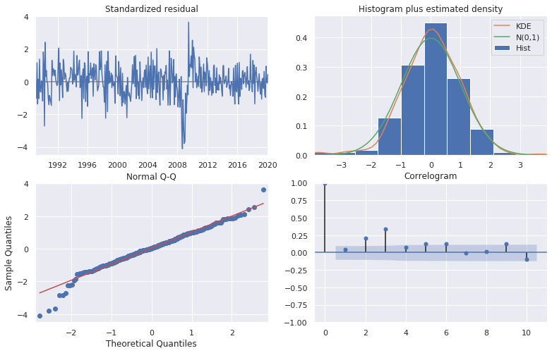

```python
results.plot_diagnostics(figsize=(13, 8))
plt.show()
```

```python
# Make in-sample predictions for last 30 values
forecast = results.get_prediction(start=-30)

# forecast mean
mean_forecast = forecast.predicted_mean

# Get confidence intervals of forecasts
confidence_intervals = forecast.conf_int()

# Select lower and upper confidence limits
lower_limits = confidence_intervals.loc[:,'lower IPGMFN']
upper_limits = confidence_intervals.loc[:,'upper IPGMFN']
```

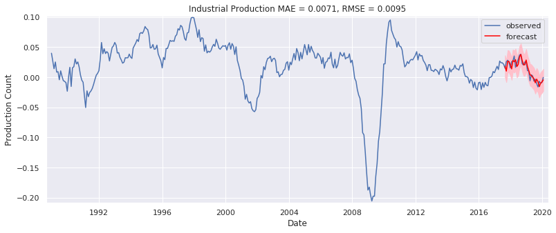

```python
plt.figure(figsize=(13, 5))

# plot the amazon data
plt.plot(industrial_production_log_diff.dropna().index, industrial_production_log_diff.dropna(), label='observed')

# Plot prediction
plt.plot(mean_forecast.index, mean_forecast.values, color='red', label='forecast')

# Shade uncertainty area
plt.fill_between(confidence_intervals.index, lower_limits, upper_limits, color='pink')

# Calculate MAE
residuals = results.resid
mae = np.mean(np.abs(residuals))

# Calculate RMSE
preds = pd.DataFrame(results.forecasts).T
preds.index = industrial_production_log_diff.dropna().index
preds. columns = ['pred']

rmse = np.sqrt(mean_squared_error(
            y_true=industrial_production_log_diff.dropna(), y_pred=preds.pred))

# set labels, legends and show plot
plt.xlabel('Date')
plt.title(f'Industrial Production MAE = {round(mae,4)}, RMSE = {round(rmse,4)}')
plt.ylabel('Production Count')
plt.margins(0.01)
plt.legend()
plt.show()
```

## Automation

### Searching over model orders to find the optimal number of lags

```python
import pmdarima as pm

results = pm.auto_arima(industrial_production_log_diff.dropna(),

d=0, # non-seasonal difference order
start_p=1, # initial guess for p
start_q=1, # initial guess for q
max_p=3, # max value of p to test
max_q=3, # max value of q to test

seasonal=True, # is the time series seasonal
m=12, # the seasonal period
D=0, # seasonal difference order
start_P=1, # initial guess for P
start_Q=1, # initial guess for Q
max_P=2, # max value of P to test
max_Q=2, # max value of Q to test

information_criterion='bic', # used to select best model
trace=True, # print results whilst training
error_action='ignore', # ignore orders that don't work
stepwise=True, # apply intelligent order search

)
```

```
Performing stepwise search to minimize bic
Fit ARIMA: (1, 0, 1)x(1, 0, 1, 12) (constant=True); AIC=-2424.020, BIC=-2400.474, Time=1.401 seconds
Fit ARIMA: (0, 0, 0)x(0, 0, 0, 12) (constant=True); AIC=-1243.961, BIC=-1236.112, Time=0.073 seconds
Fit ARIMA: (1, 0, 0)x(1, 0, 0, 12) (constant=True); AIC=-2380.072, BIC=-2364.375, Time=1.019 seconds
Fit ARIMA: (0, 0, 1)x(0, 0, 1, 12) (constant=True); AIC=-1653.220, BIC=-1637.523, Time=0.719 seconds
Fit ARIMA: (0, 0, 0)x(0, 0, 0, 12) (constant=False); AIC=-1187.299, BIC=-1183.375, Time=0.035 seconds
Fit ARIMA: (1, 0, 1)x(0, 0, 1, 12) (constant=True); AIC=-2433.749, BIC=-2414.128, Time=1.399 seconds
Fit ARIMA: (1, 0, 1)x(0, 0, 0, 12) (constant=True); AIC=-2295.596, BIC=-2279.899, Time=0.109 seconds
Fit ARIMA: (1, 0, 1)x(0, 0, 2, 12) (constant=True); AIC=-2423.176, BIC=-2399.630, Time=1.798 seconds
Fit ARIMA: (1, 0, 1)x(1, 0, 0, 12) (constant=True); AIC=-2379.572, BIC=-2359.951, Time=0.808 seconds
Fit ARIMA: (1, 0, 1)x(1, 0, 2, 12) (constant=True); AIC=-2421.091, BIC=-2393.621, Time=2.305 seconds
Fit ARIMA: (1, 0, 0)x(0, 0, 1, 12) (constant=True); AIC=-2435.051, BIC=-2419.354, Time=1.245 seconds
Fit ARIMA: (1, 0, 0)x(0, 0, 0, 12) (constant=True); AIC=-2295.811, BIC=-2284.038, Time=0.127 seconds
Fit ARIMA: (1, 0, 0)x(1, 0, 1, 12) (constant=True); AIC=-2432.713, BIC=-2413.092, Time=1.101 seconds
Fit ARIMA: (1, 0, 0)x(0, 0, 2, 12) (constant=True); AIC=-2433.114, BIC=-2413.493, Time=2.494 seconds
Fit ARIMA: (1, 0, 0)x(1, 0, 2, 12) (constant=True); AIC=-2422.755, BIC=-2399.210, Time=2.857 seconds
Fit ARIMA: (0, 0, 0)x(0, 0, 1, 12) (constant=True); AIC=-1249.581, BIC=-1237.808, Time=0.134 seconds
Fit ARIMA: (2, 0, 0)x(0, 0, 1, 12) (constant=True); AIC=-2425.471, BIC=-2405.849, Time=1.073 seconds
Fit ARIMA: (2, 0, 1)x(0, 0, 1, 12) (constant=True); AIC=-2431.882, BIC=-2408.337, Time=1.718 seconds
Total fit time: 20.430 seconds
```

```python
results = model.fit()

print(results.summary())
```

```
                                      SARIMAX Results
============================================================================================
Dep. Variable:                               IPGMFN   No. Observations:                  374
Model:             SARIMAX(2, 0, 2)x(1, 0, [1], 12)   Log Likelihood                1242.001
Date:                              Fri, 10 Apr 2020   AIC                          -2470.002
Time:                                      02:15:05   BIC                          -2442.532
Sample:                                  01-01-1989   HQIC                         -2459.095
                                       - 02-01-2020
Covariance Type:                                opg
==============================================================================
                 coef    std err          z      P>|z|      [0.025      0.975]
------------------------------------------------------------------------------
ar.L1          1.6458      0.070     23.555      0.000       1.509       1.783
ar.L2         -0.6640      0.068     -9.703      0.000      -0.798      -0.530
ma.L1         -0.7769      0.078    -10.013      0.000      -0.929      -0.625
ma.L2          0.4196      0.046      9.040      0.000       0.329       0.511
ar.S.L12       0.0514      0.088      0.581      0.561      -0.122       0.225
ma.S.L12      -0.6350      0.068     -9.276      0.000      -0.769      -0.501
sigma2      7.459e-05   5.04e-06     14.802      0.000    6.47e-05    8.45e-05
===================================================================================
Ljung-Box (Q):                       37.88   Jarque-Bera (JB):                27.28
Prob(Q):                              0.57   Prob(JB):                         0.00
Heteroskedasticity (H):               0.57   Skew:                            -0.22
Prob(H) (two-sided):                  0.00   Kurtosis:                         4.25
===================================================================================

Warnings:
[1] Covariance matrix calculated using the outer product of gradients (complex-step).
```

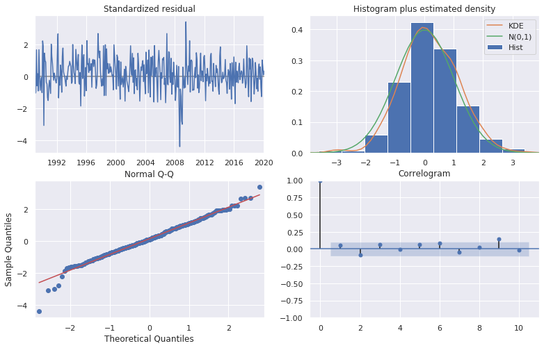

```python
results.plot_diagnostics(figsize=(13, 8))
plt.show()
```

```python
# Make in-sample predictions for last 30 values
forecast = results.get_prediction(start=-30)

# forecast mean
mean_forecast = forecast.predicted_mean

# Get confidence intervals of forecasts
confidence_intervals = forecast.conf_int()

# Select lower and upper confidence limits
lower_limits = confidence_intervals.loc[:,'lower IPGMFN']
upper_limits = confidence_intervals.loc[:,'upper IPGMFN']
```

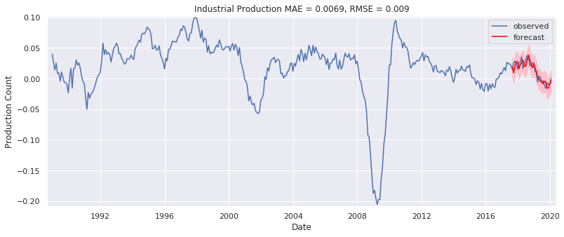

```python
plt.figure(figsize=(13, 5))

# plot the amazon data
plt.plot(industrial_production_log_diff.dropna().index, industrial_production_log_diff.dropna(), label='observed')

# Plot prediction
plt.plot(mean_forecast.index, mean_forecast.values, color='red', label='forecast')

# Shade uncertainty area
plt.fill_between(confidence_intervals.index, lower_limits, upper_limits, color='pink')

# Calculate MAE
residuals = results.resid
mae = np.mean(np.abs(residuals))

# Calculate RMSE
preds = pd.DataFrame(results.forecasts).T
preds.index = industrial_production_log_diff.dropna().index
preds. columns = ['pred']

rmse = np.sqrt(mean_squared_error(
            y_true=industrial_production_log_diff.dropna(), y_pred=preds.pred))

# set labels, legends and show plot
plt.xlabel('Date')
plt.title(f'Industrial Production MAE = {round(mae,4)}, RMSE = {round(rmse,4)}')
plt.ylabel('Production Count')
plt.margins(0.01)
plt.legend()
plt.show()
```